# XGBoost_Model

## importing all the libraries

```python
import json
from wordcloud import WordCloud
from wordcloud import WordCloud
from imblearn.over_sampling import RandomOverSampler
import matplotlib.pyplot as plt
import ast
import pandas as pd
import nltk
import string
from nltk.corpus import stopwords
from nltk.stem import PorterStemmer, WordNetLemmatizer
from sklearn.feature_extraction.text import TfidfVectorizer
import pandas as pd
from sklearn.preprocessing import LabelEncoder
from sklearn.feature_selection import SelectKBest, f_classif
# import xgboost as xgb
from sklearn.model_selection import train_test_split
from sklearn.metrics import classification_report, accuracy_score
import numpy as np
from sklearn.model_selection import train_test_split
from sklearn.preprocessing import StandardScaler
from keras.models import Sequential
from keras.layers import Dense
from keras.callbacks import EarlyStopping
import shap
from sklearn.preprocessing import LabelEncoder
from sklearn.model_selection import train_test_split
from sklearn.preprocessing import StandardScaler
import seaborn as sns
from sklearn.preprocessing import StandardScaler
from xgboost import XGBClassifier  # Corrected import
from sklearn.feature_selection import SelectFromModel
import matplotlib.pyplot as plt
import plotly.express as px
import numpy as np
import matplotlib.pyplot as plt
from sklearn.metrics import accuracy_score, confusion_matrix, ConfusionMatrixDisplay, roc_auc_score, roc_curve


import warnings

# Ignore all warnings
warnings.filterwarnings("ignore")
```

## Loading data from Json

```python
# Load JSON files as dataframes
business_df = pd.read_json('yelp_academic_dataset_business.json', lines=True)
#checkin_df = pd.read_json('/content/drive/My Drive/Colab Notebooks/yelp_dataset/yelp_academic_dataset_checkin.json', lines=True)

print("Dataframes loaded successfully!")
```

```
Dataframes loaded successfully!
```

We have worked on Business data

```python
business_df.columns
```

```
Index(['business_id', 'name', 'address', 'city', 'state', 'postal_code',
       'latitude', 'longitude', 'stars', 'review_count', 'is_open',
       'attributes', 'categories', 'hours'],
      dtype='object')
```

```python
business_df.shape
```

```
(150346, 14)
```

```python
business_df.describe()
```

|  | latitude | longitude | stars | review_count | is_open |
| --- | --- | --- | --- | --- | --- |
| count | 150346.000000 | 150346.000000 | 150346.000000 | 150346.000000 | 150346.00000 |
| mean | 36.671150 | -89.357339 | 3.596724 | 44.866561 | 0.79615 |
| std | 5.872759 | 14.918502 | 0.974421 | 121.120136 | 0.40286 |
| min | 27.555127 | -120.095137 | 1.000000 | 5.000000 | 0.00000 |
| 25% | 32.187293 | -90.357810 | 3.000000 | 8.000000 | 1.00000 |
| 50% | 38.777413 | -86.121179 | 3.500000 | 15.000000 | 1.00000 |
| 75% | 39.954036 | -75.421542 | 4.500000 | 37.000000 | 1.00000 |
| max | 53.679197 | -73.200457 | 5.000000 | 7568.000000 | 1.00000 |

```python
business_df.attributes
```

```
0                             {'ByAppointmentOnly': 'True'}
1                    {'BusinessAcceptsCreditCards': 'True'}
2         {'BikeParking': 'True', 'BusinessAcceptsCredit...
3         {'RestaurantsDelivery': 'False', 'OutdoorSeati...
4         {'BusinessAcceptsCreditCards': 'True', 'Wheelc...
                                ...
150341    {'ByAppointmentOnly': 'False', 'RestaurantsPri...
150342    {'BusinessAcceptsCreditCards': 'True', 'Restau...
150343    {'RestaurantsPriceRange2': '1', 'BusinessAccep...
150344    {'BusinessParking': '{'garage': False, 'street...
150345    {'WheelchairAccessible': 'True', 'BusinessAcce...
Name: attributes, Length: 150346, dtype: object
```

```python
business_df.attributes.shape
```

```
(150346,)
```

```python
# Assuming your dataframe is called business_df
# First, let's ensure the 'attributes' column is properly parsed

# Convert the string representation of dictionaries into actual dictionaries
business_df['attributes'] = business_df['attributes'].apply(lambda x: ast.literal_eval(str(x)) if pd.notnull(x) else {})

# Now expand the 'attributes' column into separate columns
attributes_df = business_df['attributes'].apply(pd.Series)

# Merge the expanded attributes back into the original dataframe
business_df_expanded = pd.concat([business_df, attributes_df], axis=1)

# Optionally, you can drop the original 'attributes' column if it's no longer needed
# business_df_expanded = business_df_expanded.drop(columns=['attributes'])

# Display the new dataframe with attributes as features
print(business_df_expanded.head())
```

```
              business_id                      name  \
0  Pns2l4eNsfO8kk83dixA6A  Abby Rappoport, LAC, CMQ
1  mpf3x-BjTdTEA3yCZrAYPw             The UPS Store
2  tUFrWirKiKi_TAnsVWINQQ                    Target
3  MTSW4McQd7CbVtyjqoe9mw        St Honore Pastries
4  mWMc6_wTdE0EUBKIGXDVfA  Perkiomen Valley Brewery

                           address           city state postal_code  \
0           1616 Chapala St, Ste 2  Santa Barbara    CA       93101
1  87 Grasso Plaza Shopping Center         Affton    MO       63123
2             5255 E Broadway Blvd         Tucson    AZ       85711
3                      935 Race St   Philadelphia    PA       19107
4                    101 Walnut St     Green Lane    PA       18054

    latitude   longitude  stars  review_count  ...  AcceptsInsurance  \
```

[output cut: 21 more lines]

```python
business_df_expanded.shape
```

```
(150346, 53)
```

```python
business_df_expanded.head()
```

|  | business_id | name | address | city | state | postal_code | latitude | longitude | stars | review_count | ... | AcceptsInsurance | BestNights | BYOB | Corkage | BYOBCorkage | HairSpecializesIn | Open24Hours | RestaurantsCounterService | AgesAllowed | DietaryRestrictions |
| --- | --- | --- | --- | --- | --- | --- | --- | --- | --- | --- | --- | --- | --- | --- | --- | --- | --- | --- | --- | --- | --- |
| 0 | Pns2l4eNsfO8kk83dixA6A | Abby Rappoport, LAC, CMQ | 1616 Chapala St, Ste 2 | Santa Barbara | CA | 93101 | 34.426679 | -119.711197 | 5.0 | 7 | ... | NaN | NaN | NaN | NaN | NaN | NaN | NaN | NaN | NaN | NaN |
| 1 | mpf3x-BjTdTEA3yCZrAYPw | The UPS Store | 87 Grasso Plaza Shopping Center | Affton | MO | 63123 | 38.551126 | -90.335695 | 3.0 | 15 | ... | NaN | NaN | NaN | NaN | NaN | NaN | NaN | NaN | NaN | NaN |
| 2 | tUFrWirKiKi_TAnsVWINQQ | Target | 5255 E Broadway Blvd | Tucson | AZ | 85711 | 32.223236 | -110.880452 | 3.5 | 22 | ... | NaN | NaN | NaN | NaN | NaN | NaN | NaN | NaN | NaN | NaN |
| 3 | MTSW4McQd7CbVtyjqoe9mw | St Honore Pastries | 935 Race St | Philadelphia | PA | 19107 | 39.955505 | -75.155564 | 4.0 | 80 | ... | NaN | NaN | NaN | NaN | NaN | NaN | NaN | NaN | NaN | NaN |
| 4 | mWMc6_wTdE0EUBKIGXDVfA | Perkiomen Valley Brewery | 101 Walnut St | Green Lane | PA | 18054 | 40.338183 | -75.471659 | 4.5 | 13 | ... | NaN | NaN | NaN | NaN | NaN | NaN | NaN | NaN | NaN | NaN |

5 rows × 53 columns

```python
business_df_expanded.columns
```

```
Index(['business_id', 'name', 'address', 'city', 'state', 'postal_code',
       'latitude', 'longitude', 'stars', 'review_count', 'is_open',
       'attributes', 'categories', 'hours', 'ByAppointmentOnly',
       'BusinessAcceptsCreditCards', 'BikeParking', 'RestaurantsPriceRange2',
       'CoatCheck', 'RestaurantsTakeOut', 'RestaurantsDelivery', 'Caters',
       'WiFi', 'BusinessParking', 'WheelchairAccessible', 'HappyHour',
       'OutdoorSeating', 'HasTV', 'RestaurantsReservations', 'DogsAllowed',
       'Alcohol', 'GoodForKids', 'RestaurantsAttire', 'Ambience',
       'RestaurantsTableService', 'RestaurantsGoodForGroups', 'DriveThru',
       'NoiseLevel', 'GoodForMeal', 'BusinessAcceptsBitcoin', 'Smoking',
       'Music', 'GoodForDancing', 'AcceptsInsurance', 'BestNights', 'BYOB',
       'Corkage', 'BYOBCorkage', 'HairSpecializesIn', 'Open24Hours',
       'RestaurantsCounterService', 'AgesAllowed', 'DietaryRestrictions'],
      dtype='object')
```

### Looking at the missing Values

```python
# Calculate the percentage of missing values for each column
missing_percentage = business_df_expanded.isnull().mean() * 100

# Get the columns with more than 50% missing values
columns_to_drop = missing_percentage[missing_percentage > 50].index

# Drop these columns from the dataframe
business_df_expanded = business_df_expanded.drop(columns=columns_to_drop)

# Print the columns that were dropped
print(f"Columns with more than 50% missing values dropped: {columns_to_drop}")
```

```
Columns with more than 50% missing values dropped: Index(['ByAppointmentOnly', 'BikeParking', 'CoatCheck', 'RestaurantsTakeOut',
       'RestaurantsDelivery', 'Caters', 'WiFi', 'WheelchairAccessible',
       'HappyHour', 'OutdoorSeating', 'HasTV', 'RestaurantsReservations',
       'DogsAllowed', 'Alcohol', 'GoodForKids', 'RestaurantsAttire',
       'Ambience', 'RestaurantsTableService', 'RestaurantsGoodForGroups',
       'DriveThru', 'NoiseLevel', 'GoodForMeal', 'BusinessAcceptsBitcoin',
       'Smoking', 'Music', 'GoodForDancing', 'AcceptsInsurance', 'BestNights',
       'BYOB', 'Corkage', 'BYOBCorkage', 'HairSpecializesIn', 'Open24Hours',
       'RestaurantsCounterService', 'AgesAllowed', 'DietaryRestrictions'],
      dtype='object')
```

```python
business_df_expanded.shape
```

```
(150346, 17)
```

```python
# Check for missing values in the dataframe
missing_values = business_df_expanded.isnull().sum()

# Handle missing values (this can be customized depending on your data)
# Option 1: Fill missing numerical values with the median or mean
business_df_expanded['stars'].fillna(business_df_expanded['stars'].median(), inplace=True)

# Option 2: Fill missing categorical values with 'Unknown' or mode
for column in business_df_expanded.select_dtypes(include='object').columns:
    business_df_expanded[column].fillna('Unknown', inplace=True)

# Option 3: Drop columns with too many missing values (if needed)
# business_df_expanded = business_df_expanded.drop(columns=['column_with_many_missing_values'])
```

```python
business_df_expanded.isnull().sum().sum()
```

```
0
```

```python
business_df_expanded.columns
```

```
Index(['business_id', 'name', 'address', 'city', 'state', 'postal_code',
       'latitude', 'longitude', 'stars', 'review_count', 'is_open',
       'attributes', 'categories', 'hours', 'BusinessAcceptsCreditCards',
       'RestaurantsPriceRange2', 'BusinessParking'],
      dtype='object')
```

```python
# Columns that need label encoding
binary_columns = ['is_open', 'BusinessAcceptsCreditCards']

label_encoder = LabelEncoder()
for column in binary_columns:
    business_df_expanded[column] = label_encoder.fit_transform(business_df_expanded[column].astype(str))
```

```python
business_df_expanded.shape
```

```
(150346, 17)
```

```python
business_df_expanded.info()
```

```
<class 'pandas.core.frame.DataFrame'>
RangeIndex: 150346 entries, 0 to 150345
Data columns (total 17 columns):
 #   Column                      Non-Null Count   Dtype
---  ------                      --------------   -----
 0   business_id                 150346 non-null  object
 1   name                        150346 non-null  object
 2   address                     150346 non-null  object
 3   city                        150346 non-null  object
 4   state                       150346 non-null  object
 5   postal_code                 150346 non-null  object
 6   latitude                    150346 non-null  float64
 7   longitude                   150346 non-null  float64
 8   stars                       150346 non-null  float64
 9   review_count                150346 non-null  int64
 10  is_open                     150346 non-null  int64
 11  attributes                  150346 non-null  object
 12  categories                  150346 non-null  object
 13  hours                       150346 non-null  object
 14  BusinessAcceptsCreditCards  150346 non-null  int64
 15  RestaurantsPriceRange2      150346 non-null  object
 16  BusinessParking             150346 non-null  object
dtypes: float64(3), int64(3), object(11)
memory usage: 19.5+ MB
```

```python
business_df_expanded['categories']
```

```
0         Doctors, Traditional Chinese Medicine, Naturop...
1         Shipping Centers, Local Services, Notaries, Ma...
2         Department Stores, Shopping, Fashion, Home & G...
3         Restaurants, Food, Bubble Tea, Coffee & Tea, B...
4                                 Brewpubs, Breweries, Food
                                ...
150341                           Nail Salons, Beauty & Spas
150342    Pets, Nurseries & Gardening, Pet Stores, Hobby...
150343    Shopping, Jewelry, Piercing, Toy Stores, Beaut...
150344    Fitness/Exercise Equipment, Eyewear & Optician...
150345    Beauty & Spas, Permanent Makeup, Piercing, Tattoo
Name: categories, Length: 150346, dtype: object
```

### One Hot Encoding Top 10 categories

```python
#One Hot Encoding Top 10 categories

#Splitting the categories into separate items
business_df_expanded['categories_split'] = business_df_expanded['categories'].apply(lambda x: x.split(', ') if isinstance(x, str) else [])

#Getting the top 10 most common categories
all_categories = business_df_expanded['categories_split'].explode()  # Flatten the list of categories
top_10_categories = all_categories.value_counts().head(10).index.tolist()

#One-hot encoding the top 10 categories
for category in top_10_categories:
    business_df_expanded[category] = business_df_expanded['categories_split'].apply(lambda x: 1 if category in x else 0)

#Dropping the temporary 'categories_split' column
business_df_expanded = business_df_expanded.drop(columns=['categories_split'])

business_df_expanded.head()
```

|  | business_id | name | address | city | state | postal_code | latitude | longitude | stars | review_count | ... | Restaurants | Food | Shopping | Home Services | Beauty & Spas | Nightlife | Health & Medical | Local Services | Bars | Automotive |
| --- | --- | --- | --- | --- | --- | --- | --- | --- | --- | --- | --- | --- | --- | --- | --- | --- | --- | --- | --- | --- | --- |
| 0 | Pns2l4eNsfO8kk83dixA6A | Abby Rappoport, LAC, CMQ | 1616 Chapala St, Ste 2 | Santa Barbara | CA | 93101 | 34.426679 | -119.711197 | 5.0 | 7 | ... | 0 | 0 | 0 | 0 | 0 | 0 | 1 | 0 | 0 | 0 |
| 1 | mpf3x-BjTdTEA3yCZrAYPw | The UPS Store | 87 Grasso Plaza Shopping Center | Affton | MO | 63123 | 38.551126 | -90.335695 | 3.0 | 15 | ... | 0 | 0 | 0 | 0 | 0 | 0 | 0 | 1 | 0 | 0 |
| 2 | tUFrWirKiKi_TAnsVWINQQ | Target | 5255 E Broadway Blvd | Tucson | AZ | 85711 | 32.223236 | -110.880452 | 3.5 | 22 | ... | 0 | 0 | 1 | 0 | 0 | 0 | 0 | 0 | 0 | 0 |
| 3 | MTSW4McQd7CbVtyjqoe9mw | St Honore Pastries | 935 Race St | Philadelphia | PA | 19107 | 39.955505 | -75.155564 | 4.0 | 80 | ... | 1 | 1 | 0 | 0 | 0 | 0 | 0 | 0 | 0 | 0 |
| 4 | mWMc6_wTdE0EUBKIGXDVfA | Perkiomen Valley Brewery | 101 Walnut St | Green Lane | PA | 18054 | 40.338183 | -75.471659 | 4.5 | 13 | ... | 0 | 1 | 0 | 0 | 0 | 0 | 0 | 0 | 0 | 0 |

5 rows × 27 columns

```python
business_df_expanded.shape
```

```
(150346, 27)
```

```python
# Drop irrelevant columns
business_df_expanded = business_df_expanded.drop(columns=[ 'name', 'address'])
#'name', 'address', 'attributes', 'categories', 'hours'
```

```python
business_df_expanded = business_df_expanded.drop(columns=[ 'attributes', 'categories', 'hours'])
```

```python
business_df_expanded.shape
```

```
(150346, 22)
```

```python
business_df_expanded.info()
```

```
<class 'pandas.core.frame.DataFrame'>
RangeIndex: 150346 entries, 0 to 150345
Data columns (total 22 columns):
 #   Column                      Non-Null Count   Dtype
---  ------                      --------------   -----
 0   business_id                 150346 non-null  object
 1   city                        150346 non-null  object
 2   state                       150346 non-null  object
 3   postal_code                 150346 non-null  object
 4   latitude                    150346 non-null  float64
 5   longitude                   150346 non-null  float64
 6   stars                       150346 non-null  float64
 7   review_count                150346 non-null  int64
 8   is_open                     150346 non-null  int64
 9   BusinessAcceptsCreditCards  150346 non-null  int64
 10  RestaurantsPriceRange2      150346 non-null  object
 11  BusinessParking             150346 non-null  object
 12  Restaurants                 150346 non-null  int64
 13  Food                        150346 non-null  int64
 14  Shopping                    150346 non-null  int64
 15  Home Services               150346 non-null  int64
 16  Beauty & Spas               150346 non-null  int64
 17  Nightlife                   150346 non-null  int64
 18  Health & Medical            150346 non-null  int64
 19  Local Services              150346 non-null  int64
 20  Bars                        150346 non-null  int64
 21  Automotive                  150346 non-null  int64
dtypes: float64(3), int64(13), object(6)
memory usage: 25.2+ MB
```

```python
business_df_expanded.isnull().sum()
```

```
business_id                   0
city                          0
state                         0
postal_code                   0
latitude                      0
longitude                     0
stars                         0
review_count                  0
is_open                       0
BusinessAcceptsCreditCards    0
RestaurantsPriceRange2        0
BusinessParking               0
Restaurants                   0
Food                          0
Shopping                      0
Home Services                 0
Beauty & Spas                 0
Nightlife                     0
Health & Medical              0
Local Services                0
Bars                          0
Automotive                    0
dtype: int64
```

```python
business_df_expanded['BusinessParking'].head()
```

```
0                                              Unknown
1                                              Unknown
2    {'garage': False, 'street': False, 'validated'...
3    {'garage': False, 'street': True, 'validated':...
4    {'garage': None, 'street': None, 'validated': ...
Name: BusinessParking, dtype: object
```

```python
(business_df_expanded['BusinessParking'] == 'Unknown').sum()
```

```
59261
```

```python
business_df_expanded['BusinessParking'].isna().sum()
```

```
0
```

```python
business_df_expanded = business_df_expanded.dropna(subset=['BusinessParking'])
```

```python
business_df_expanded.shape
```

```
(150346, 22)
```

```python
(business_df_expanded['BusinessParking'] == 'Unknown').sum()
```

```
59261
```

```python
# Step 1: Remove rows with 'Unknown' in the 'BusinessParking' column
business_df_expanded = business_df_expanded[business_df_expanded['BusinessParking'] != 'Unknown']
```

```python
business_df_expanded.shape
```

```
(91085, 22)
```

```python
business_df_expanded['BusinessParking'].iloc[0]
```

```
"{'garage': False, 'street': False, 'validated': False, 'lot': True, 'valet': False}"
```

### Creating the Target Variable using existing dictionary in Business_parking

```python
import ast
import pandas as pd

# Function to safely parse each entry in 'BusinessParking'
def safe_literal_eval(item):
    try:
        # Try to parse the item if it's a string
        if isinstance(item, str):
            return ast.literal_eval(item)
        # Return the item if it's already a dictionary
        elif isinstance(item, dict):
            return item
        # Return an empty dictionary for any other type
        return {}
    except (ValueError, SyntaxError):
        return {}

# Apply the parsing function to each element in the 'BusinessParking' column
business_df_expanded['BusinessParking'] = business_df_expanded['BusinessParking'].apply(safe_literal_eval)

# Normalize the 'BusinessParking' dictionary into separate columns
df_business_latest = pd.json_normalize(business_df_expanded['BusinessParking'])

# Combine the new dataframe with the original one (if needed)
business_df_expanded = pd.concat([business_df_expanded, df_business_latest], axis=1)

# Drop the 'BusinessParking' column if no longer needed
business_df_expanded = business_df_expanded.drop(columns=['BusinessParking'])

# Check the updated dataframe
print(business_df_expanded.head())
```

```
              business_id          city state postal_code   latitude  \
2  tUFrWirKiKi_TAnsVWINQQ        Tucson    AZ       85711  32.223236
3  MTSW4McQd7CbVtyjqoe9mw  Philadelphia    PA       19107  39.955505
4  mWMc6_wTdE0EUBKIGXDVfA    Green Lane    PA       18054  40.338183
5  CF33F8-E6oudUQ46HnavjQ  Ashland City    TN       37015  36.269593
6  n_0UpQx1hsNbnPUSlodU8w     Brentwood    MO       63144  38.627695

    longitude  stars  review_count  is_open  BusinessAcceptsCreditCards  ...  \
2 -110.880452    3.5          22.0      0.0                         2.0  ...
3  -75.155564    4.0          80.0      1.0                         0.0  ...
4  -75.471659    4.5          13.0      1.0                         2.0  ...
5  -87.058943    2.0           6.0      1.0                         2.0  ...
6  -90.340465    2.5          13.0      1.0                         2.0  ...

  Nightlife  Health & Medical  Local Services  Bars  Automotive  garage  \
2       0.0               0.0             0.0   0.0         0.0    None
3       0.0               0.0             0.0   0.0         0.0     NaN
4       0.0               0.0             0.0   0.0         0.0   False
5       0.0               0.0             0.0   0.0         0.0   False
6       0.0               0.0             0.0   0.0         0.0   False

   street  validated    lot  valet
2    None       None   True  False
3     NaN        NaN    NaN    NaN
4   False      False   True  False
5   False      False   True  False
6   False      False  False  False

[5 rows x 26 columns]
```

```python
business_df_expanded.shape
```

```
(126947, 26)
```

```python
business_df_expanded.info()
```

```
<class 'pandas.core.frame.DataFrame'>
Index: 126947 entries, 2 to 91084
Data columns (total 26 columns):
 #   Column                      Non-Null Count  Dtype
---  ------                      --------------  -----
 0   business_id                 91085 non-null  object
 1   city                        91085 non-null  object
 2   state                       91085 non-null  object
 3   postal_code                 91085 non-null  object
 4   latitude                    91085 non-null  float64
 5   longitude                   91085 non-null  float64
 6   stars                       91085 non-null  float64
 7   review_count                91085 non-null  float64
 8   is_open                     91085 non-null  float64
 9   BusinessAcceptsCreditCards  91085 non-null  float64
```

[output cut: 18 more lines]

```python
business_df_expanded = business_df_expanded.dropna(subset=['validated'])
```

```python
business_df_expanded.info()
```

```
<class 'pandas.core.frame.DataFrame'>
Index: 86654 entries, 4 to 91084
Data columns (total 26 columns):
 #   Column                      Non-Null Count  Dtype
---  ------                      --------------  -----
 0   business_id                 52569 non-null  object
 1   city                        52569 non-null  object
 2   state                       52569 non-null  object
 3   postal_code                 52569 non-null  object
 4   latitude                    52569 non-null  float64
 5   longitude                   52569 non-null  float64
 6   stars                       52569 non-null  float64
 7   review_count                52569 non-null  float64
 8   is_open                     52569 non-null  float64
 9   BusinessAcceptsCreditCards  52569 non-null  float64
```

[output cut: 18 more lines]

```python
business_df_expanded2 =business_df_expanded.copy()
```

```python
business_df_expanded2.reset_index(inplace=True,drop=True)
```

#### We have a lot of imbalance in target column but will proceed with this for of now till deployment

```python
business_df_expanded2['validated'].value_counts()
```

```
validated
False    85815
True       839
Name: count, dtype: int64
```

```python
business_df_expanded2.columns
```

```
Index(['business_id', 'city', 'state', 'postal_code', 'latitude', 'longitude',
       'stars', 'review_count', 'is_open', 'BusinessAcceptsCreditCards',
       'RestaurantsPriceRange2', 'Restaurants', 'Food', 'Shopping',
       'Home Services', 'Beauty & Spas', 'Nightlife', 'Health & Medical',
       'Local Services', 'Bars', 'Automotive', 'garage', 'street', 'validated',
       'lot', 'valet'],
      dtype='object')
```

```python
business_df_expanded2.dtypes
```

```
business_id                    object
city                           object
state                          object
postal_code                    object
latitude                      float64
longitude                     float64
stars                         float64
review_count                  float64
is_open                       float64
BusinessAcceptsCreditCards    float64
RestaurantsPriceRange2         object
Restaurants                   float64
Food                          float64
Shopping                      float64
Home Services                 float64
Beauty & Spas                 float64
Nightlife                     float64
Health & Medical              float64
Local Services                float64
Bars                          float64
Automotive                    float64
garage                         object
street                         object
validated                      object
lot                            object
valet                          object
dtype: object
```

```python
business_df_expanded2.shape
```

```
(86654, 26)
```

More exploration on columns with missing values and not

```python
import pandas as pd

# Assuming your DataFrame is called 'df'
columns_with_missing = business_df_expanded2.columns[business_df_expanded2.isnull().any()].tolist()
columns_without_missing = business_df_expanded2.columns[~business_df_expanded2.isnull().any()].tolist()

print("Columns with missing values:", columns_with_missing)
print("Columns without missing values:", columns_without_missing)

# Check if all columns have missing values
all_columns_have_missing = business_df_expanded2.isnull().any().all()

if all_columns_have_missing:
    print("All columns have at least one missing value.")
else:
    print("Not all columns have missing values.")
```

```
Columns with missing values: ['business_id', 'city', 'state', 'postal_code', 'latitude', 'longitude', 'stars', 'review_count', 'is_open', 'BusinessAcceptsCreditCards', 'RestaurantsPriceRange2', 'Restaurants', 'Food', 'Shopping', 'Home Services', 'Beauty & Spas', 'Nightlife', 'Health & Medical', 'Loc…
Columns without missing values: ['validated', 'valet']
Not all columns have missing values.
```

```python
missing_counts = business_df_expanded2.isnull().sum()
```

```python
missing_counts
```

```
business_id                   34085
city                          34085
state                         34085
postal_code                   34085
latitude                      34085
longitude                     34085
stars                         34085
review_count                  34085
is_open                       34085
BusinessAcceptsCreditCards    34085
RestaurantsPriceRange2        34085
Restaurants                   34085
Food                          34085
Shopping                      34085
Home Services                 34085
Beauty & Spas                 34085
Nightlife                     34085
Health & Medical              34085
Local Services                34085
Bars                          34085
Automotive                    34085
garage                          895
street                         1977
validated                         0
lot                            1480
valet                             0
dtype: int64
```

Handle missing values in numerical and categorical column

```python
# Fill numerical columns with median
business_df_expanded2['stars'].fillna(business_df_expanded2['stars'].median(), inplace=True)
business_df_expanded2['review_count'].fillna(business_df_expanded2['review_count'].median(), inplace=True)

# Fill 'is_open' with the mode (most frequent value)
business_df_expanded2['is_open'].fillna(business_df_expanded2['is_open'].mode()[0], inplace=True)
```

Imputation

```python
from sklearn.impute import KNNImputer

knn_imputer = KNNImputer(n_neighbors=5)
numeric_columns = ['latitude', 'longitude', 'stars', 'review_count', 'is_open']
business_df_expanded2[numeric_columns] = knn_imputer.fit_transform(business_df_expanded2[numeric_columns])
```

```python
# Check for any remaining missing values
print(business_df_expanded2.isnull().sum())
```

```
business_id                   34085
city                          34085
state                         34085
postal_code                   34085
latitude                          0
longitude                         0
stars                             0
review_count                      0
is_open                           0
BusinessAcceptsCreditCards    34085
RestaurantsPriceRange2        34085
Restaurants                   34085
Food                          34085
Shopping                      34085
Home Services                 34085
Beauty & Spas                 34085
Nightlife                     34085
Health & Medical              34085
Local Services                34085
Bars                          34085
Automotive                    34085
garage                          895
street                         1977
validated                         0
lot                            1480
valet                             0
dtype: int64
```

```python
# Fill parking-related columns with a default value
business_df_expanded2['garage'].fillna(False, inplace=True)
business_df_expanded2['street'].fillna(False, inplace=True)
business_df_expanded2['lot'].fillna(False, inplace=True)
```

```python
# Fill categorical columns with the mode
for column in ['business_id', 'city', 'state', 'postal_code',
               'BusinessAcceptsCreditCards', 'RestaurantsPriceRange2',
               'Restaurants', 'Food', 'Shopping', 'Home Services',
               'Beauty & Spas', 'Nightlife', 'Health & Medical',
               'Local Services', 'Bars', 'Automotive']:
    mode_value = business_df_expanded2[column].mode()[0]  # Get the mode
    business_df_expanded2[column].fillna(mode_value, inplace=True)
```

```python
print(business_df_expanded2.isnull().sum())
```

```
business_id                   0
city                          0
state                         0
postal_code                   0
latitude                      0
longitude                     0
stars                         0
review_count                  0
is_open                       0
BusinessAcceptsCreditCards    0
RestaurantsPriceRange2        0
Restaurants                   0
Food                          0
Shopping                      0
Home Services                 0
Beauty & Spas                 0
Nightlife                     0
Health & Medical              0
Local Services                0
Bars                          0
Automotive                    0
garage                        0
street                        0
validated                     0
lot                           0
valet                         0
dtype: int64
```

```python
# Remove irrelevant features
features_to_drop = [
    'business_id',
    'postal_code',   # Add others based on relevance analysis
]

# Remove irrelevant features
business_df_expanded2.drop(columns=features_to_drop, inplace=True)
```

```python
business_df_expanded2.shape
```

```
(86654, 24)
```

```python
print(business_df_expanded2.describe())
```

```
           latitude     longitude         stars  review_count       is_open  \
count  86654.000000  86654.000000  86654.000000  86654.000000  86654.000000
mean      36.253140    -87.303762      3.785394     46.271944      0.838588
std        4.723488     11.495601      0.687972    111.078090      0.367913
min       27.555127   -120.082200      1.000000      5.000000      0.000000
25%       35.292433    -86.767052      3.500000     17.000000      1.000000
50%       35.292433    -84.878444      4.000000     22.000000      1.000000
75%       39.767709    -82.666908      4.000000     30.000000      1.000000
max       53.648837    -74.664459      5.000000   5070.000000      1.000000

       BusinessAcceptsCreditCards   Restaurants          Food      Shopping  \
count                86654.000000  86654.000000  86654.000000  86654.000000
mean                     2.013202      0.696933      0.164170      0.131742
std                      0.374435      0.459587      0.370432      0.338212
min                      0.000000      0.000000      0.000000      0.000000
25%                      2.000000      0.000000      0.000000      0.000000
50%                      2.000000      1.000000      0.000000      0.000000
75%                      2.000000      1.000000      0.000000      0.000000
max                      3.000000      1.000000      1.000000      1.000000

       Home Services  Beauty & Spas     Nightlife  Health & Medical  \
count   86654.000000   86654.000000  86654.000000      86654.000000
mean        0.011609       0.082200      0.073834          0.023173
std         0.107120       0.274671      0.261502          0.150452
min         0.000000       0.000000      0.000000          0.000000
25%         0.000000       0.000000      0.000000          0.000000
50%         0.000000       0.000000      0.000000          0.000000
75%         0.000000       0.000000      0.000000          0.000000
max         1.000000       1.000000      1.000000          1.000000

       Local Services          Bars    Automotive
count    86654.000000  86654.000000  86654.000000
mean         0.026127      0.067314      0.006151
std          0.159514      0.250566      0.078187
min          0.000000      0.000000      0.000000
25%          0.000000      0.000000      0.000000
50%          0.000000      0.000000      0.000000
75%          0.000000      0.000000      0.000000
max          1.000000      1.000000      1.000000
```

```python
# Check the data types of all columns
print(business_df_expanded2.dtypes)

# Identify which columns are non-numeric
non_numeric_cols = business_df_expanded2.select_dtypes(include='object').columns
print("Non-numeric columns:", non_numeric_cols)
```

```
city                           object
state                          object
latitude                      float64
longitude                     float64
stars                         float64
review_count                  float64
is_open                       float64
BusinessAcceptsCreditCards    float64
RestaurantsPriceRange2         object
Restaurants                   float64
Food                          float64
Shopping                      float64
Home Services                 float64
Beauty & Spas                 float64
Nightlife                     float64
Health & Medical              float64
Local Services                float64
Bars                          float64
Automotive                    float64
garage                           bool
street                           bool
validated                      object
lot                              bool
valet                          object
dtype: object
Non-numeric columns: Index(['city', 'state', 'RestaurantsPriceRange2', 'validated', 'valet'], dtype='object')
```

Creating the Copy of the df

```python
import pandas as pd
from sklearn.preprocessing import LabelEncoder

# Creating a copy of your DataFrame to avoid modifying the original
business_df_encoded = business_df_expanded2.copy()

# Initialize LabelEncoder
le = LabelEncoder()

# Encode categorical features
categorical_cols = ['city', 'state', 'RestaurantsPriceRange2', 'valet']

for col in categorical_cols:
    business_df_encoded[col] = le.fit_transform(business_df_encoded[col].astype(str))

# Now check the transformed DataFrame
print(business_df_encoded.dtypes)

# Verify the head of the DataFrame
print(business_df_encoded.head())
```

```
city                            int64
state                           int64
latitude                      float64
longitude                     float64
stars                         float64
review_count                  float64
is_open                       float64
BusinessAcceptsCreditCards    float64
RestaurantsPriceRange2          int64
Restaurants                   float64
Food                          float64
Shopping                      float64
Home Services                 float64
Beauty & Spas                 float64
Nightlife                     float64
Health & Medical              float64
Local Services                float64
Bars                          float64
Automotive                    float64
garage                           bool
street                           bool
validated                      object
lot                              bool
valet                           int64
dtype: object
   city  state   latitude  longitude  stars  review_count  is_open  \
0   294     15  40.338183 -75.471659    4.5          13.0      1.0
1    16     17  36.269593 -87.058943    2.0           6.0      1.0
2    71     11  38.627695 -90.340465    2.5          13.0      1.0
3     4     11  38.565165 -90.321087    3.0          19.0      0.0
4   385      5  28.190459 -82.457380    3.5           6.0      1.0

   BusinessAcceptsCreditCards  RestaurantsPriceRange2  Restaurants  ...  \
0                         2.0                       5          0.0  ...
1                         2.0                       0          1.0  ...
2                         2.0                       1          0.0  ...
3                         2.0                       0          1.0  ...
4                         2.0                       1          0.0  ...

   Nightlife  Health & Medical  Local Services  Bars  Automotive  garage  \
0        0.0               0.0             0.0   0.0         0.0   False
1        0.0               0.0             0.0   0.0         0.0   False
2        0.0               0.0             0.0   0.0         0.0   False
3        1.0               0.0             0.0   1.0         0.0   False
4        0.0               0.0             0.0   0.0         0.0   False

   street  validated    lot  valet
0   False      False   True      0
1   False      False   True      0
2   False      False  False      0
3   False      False  False      0
4   False      False   True      0

[5 rows x 24 columns]
```

```python
# Check the data types of all columns
print(business_df_encoded.dtypes)

# Identify which columns are non-numeric
non_numeric_cols = business_df_encoded.select_dtypes(include='object').columns
print("Non-numeric columns:", non_numeric_cols)
```

```
city                            int64
state                           int64
latitude                      float64
longitude                     float64
stars                         float64
review_count                  float64
is_open                       float64
BusinessAcceptsCreditCards    float64
RestaurantsPriceRange2          int64
Restaurants                   float64
Food                          float64
Shopping                      float64
Home Services                 float64
Beauty & Spas                 float64
Nightlife                     float64
Health & Medical              float64
Local Services                float64
Bars                          float64
Automotive                    float64
garage                           bool
street                           bool
validated                      object
lot                              bool
valet                           int64
dtype: object
Non-numeric columns: Index(['validated'], dtype='object')
```

Tried some correlation

```
                                city     state  latitude  longitude     stars  \
city                        1.000000  0.035619 -0.363169   0.019474  0.093522
state                       0.035619  1.000000  0.087559   0.522179  0.116372
latitude                   -0.363169  0.087559  1.000000  -0.182034 -0.093465
longitude                   0.019474  0.522179 -0.182034   1.000000  0.001277
stars                       0.093522  0.116372 -0.093465   0.001277  1.000000
review_count                0.008583 -0.073786 -0.035098  -0.046893  0.033414
is_open                     0.068863  0.166463 -0.068642   0.050511  0.142242
BusinessAcceptsCreditCards -0.113191 -0.195512  0.216485  -0.183761 -0.054811
RestaurantsPriceRange2     -0.040998 -0.099636  0.017418  -0.042790  0.125340
Restaurants                 0.116926  0.306377 -0.072141   0.147347  0.030130
Food                       -0.083149 -0.182170  0.056543  -0.040697 -0.074333
Shopping                   -0.067997 -0.185210  0.054620  -0.107521 -0.079011
Home Services              -0.017817 -0.043681  0.007206  -0.021751 -0.037991
Beauty & Spas              -0.050219 -0.134472  0.025562  -0.049048  0.020712
Nightlife                  -0.025444 -0.116411  0.015052  -0.039950 -0.056189
Health & Medical           -0.020806 -0.076189  0.008990  -0.041049  0.006737
Local Services             -0.029372 -0.071691  0.017492  -0.044116 -0.028039
Bars                       -0.025553 -0.111177  0.012748  -0.035769 -0.053871
Automotive                 -0.007795 -0.040883 -0.002649  -0.028101 -0.053982
garage                     -0.000110 -0.006093  0.004958  -0.004703  0.002967
street                     -0.001975 -0.002869 -0.001652  -0.001979  0.001366
lot                         0.002144 -0.000793  0.001206   0.004187 -0.001470
valet                      -0.001991  0.001002  0.000947  -0.005249  0.000508

                            review_count   is_open  \
city                            0.008583  0.068863
state                          -0.073786  0.166463
latitude                       -0.035098 -0.068642
longitude                      -0.046893  0.050511
stars                           0.033414  0.142242
review_count                    1.000000  0.008351
is_open                         0.008351  1.000000
BusinessAcceptsCreditCards     -0.039546  0.015217
RestaurantsPriceRange2         -0.052977  0.051063
Restaurants                     0.115067  0.055351
Food                            0.091183 -0.130296
Shopping                       -0.083810 -0.032212
Home Services                  -0.023919  0.025001
Beauty & Spas                  -0.049206  0.009106
```

[output cut: 121 more lines]

```
Food                        0.005433  0.001565 -0.004932
Shopping                   -0.001160 -0.001331 -0.000287
Home Services              -0.004232 -0.001892 -0.003289
Beauty & Spas              -0.003429  0.004879 -0.001910
Nightlife                   0.006953  0.000212  0.002865
Health & Medical            0.002019  0.000528 -0.001661
Local Services             -0.004809 -0.001809 -0.001177
Bars                        0.005817  0.000624  0.001381
Automotive                  0.000692  0.000182 -0.001111
garage                      0.148540 -0.112410  0.163936
street                      1.000000 -0.263319  0.054964
lot                        -0.263319  1.000000 -0.026681
valet                       0.054964 -0.026681  1.000000

[23 rows x 23 columns]
```

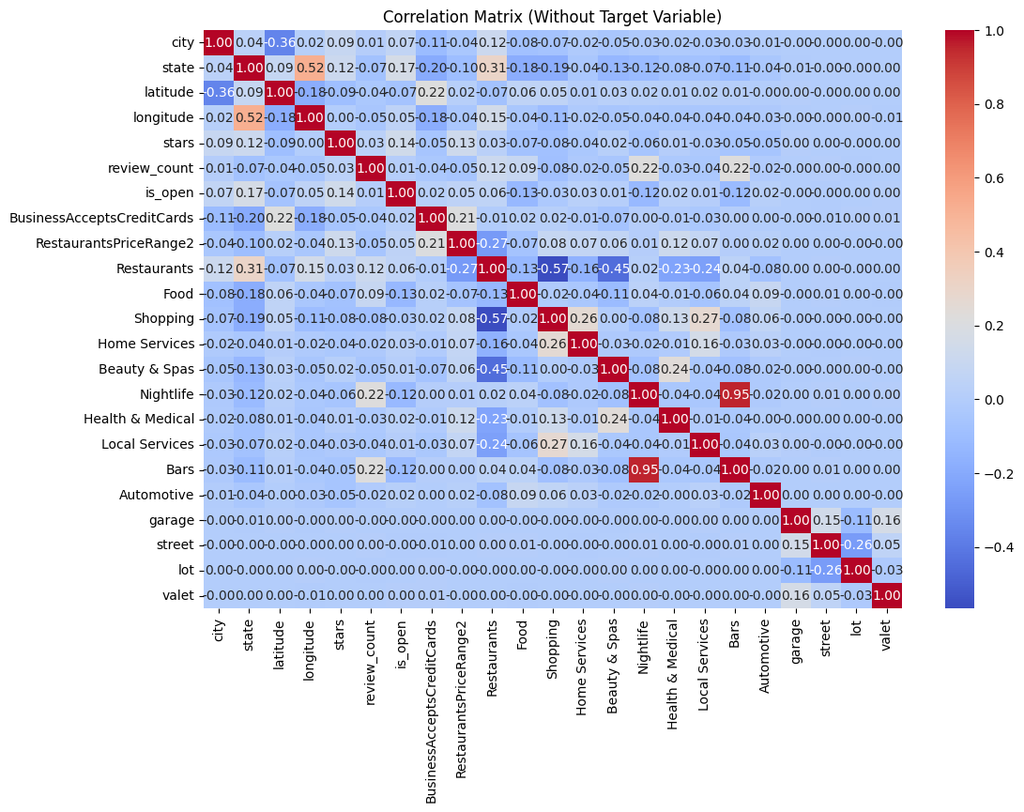

```python
# Step 1: Creating a new DataFrame without the target variable 'validated'
features_df = business_df_encoded.drop(columns=['validated'])

# Step 2: Calculate the correlation matrix
correlation_matrix = features_df.corr()

# Step 3: Display the correlation matrix
print(correlation_matrix)

# Optional: Visualize the correlation matrix using a heatmap (requires seaborn)
import seaborn as sns
import matplotlib.pyplot as plt

plt.figure(figsize=(12, 8))
sns.heatmap(correlation_matrix, annot=True, fmt=".2f", cmap='coolwarm')
plt.title('Correlation Matrix (Without Target Variable)')
plt.show()
```

### Outlier analysis and Handling

```python
# Assuming your DataFrame is named business_df_encoded

# Function to identify outliers based on IQR
def detect_outliers_iqr(df):
    outliers = pd.DataFrame()
    for column in df.select_dtypes(include=['float64', 'int64']).columns:
        Q1 = df[column].quantile(0.25)
        Q3 = df[column].quantile(0.75)
        IQR = Q3 - Q1

        # Define outlier bounds
        lower_bound = Q1 - 1.5 * IQR
        upper_bound = Q3 + 1.5 * IQR

        # Identify outliers
        outlier_data = df[(df[column] < lower_bound) | (df[column] > upper_bound)]
        outlier_data['feature'] = column
        outliers = pd.concat([outliers, outlier_data])

    return outliers

# Get outliers from the entire dataset
outliers_iqr = detect_outliers_iqr(business_df_encoded)
print(outliers_iqr)
```

```
       city  state   latitude  longitude  stars  review_count  is_open  \
0       294     15  40.338183 -75.471659    4.5          13.0      1.0
1        16     17  36.269593 -87.058943    2.0           6.0      1.0
2        71     11  38.627695 -90.340465    2.5          13.0      1.0
3         4     11  38.565165 -90.321087    3.0          19.0      0.0
4       385      5  28.190459 -82.457380    3.5           6.0      1.0
...     ...    ...        ...        ...    ...           ...      ...
86415   579     15  35.292433 -84.878444    4.0          22.0      1.0
86471   579     15  35.292433 -84.878444    4.0          22.0      1.0
86530   579     15  35.292433 -84.878444    4.0          22.0      1.0
86543   579     15  35.292433 -84.878444    4.0          22.0      1.0
86605   579     15  35.292433 -84.878444    4.0          22.0      1.0

       BusinessAcceptsCreditCards  RestaurantsPriceRange2  Restaurants  ...  \
0                             2.0                       5          0.0  ...
```

[output cut: 38 more lines]

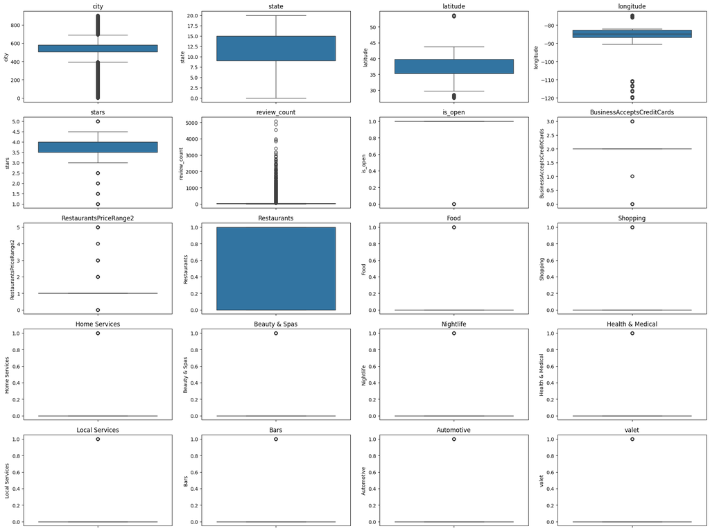

```python
# Select numerical columns for visualization
numerical_columns = business_df_encoded.select_dtypes(include=['float64', 'int64']).columns

# Create box plots for each numerical column
plt.figure(figsize=(20, 15))
for i, column in enumerate(numerical_columns):
    plt.subplot(5, 4, i + 1)  # Adjust number of rows/columns based on your numerical features
    sns.boxplot(y=column, data=business_df_encoded)
    plt.title(column)
plt.tight_layout()
plt.show()
```

Graph doesn't make much sense but we can see some of the outliers to be handled soon

```python
outlier_counts = outliers_iqr['feature'].value_counts()
print(outlier_counts)
```

```
feature
city                          29195
longitude                     26837
RestaurantsPriceRange2        26690
review_count                  14904
Food                          14226
is_open                       13987
stars                         12279
Shopping                      11416
latitude                      11073
Beauty & Spas                  7123
BusinessAcceptsCreditCards     6674
Nightlife                      6398
Bars                           5833
Local Services                 2264
Health & Medical               2008
valet                          1458
Home Services                  1006
Automotive                      533
Name: count, dtype: int64
```

```python
## Handled missing values
def cap_outliers(df, column):
    lower_bound = df[column].quantile(0.01)
    upper_bound = df[column].quantile(0.99)
    df[column] = np.where(df[column] < lower_bound, lower_bound, df[column])
    df[column] = np.where(df[column] > upper_bound, upper_bound, df[column])

# List of columns with outliers
outlier_columns = [
    'city', 'RestaurantsPriceRange2', 'review_count', 'latitude',
    'Food', 'is_open', 'stars', 'Shopping', 'Beauty & Spas',
    'BusinessAcceptsCreditCards', 'Nightlife', 'Bars', 'longitude',
    'Local Services', 'Health & Medical', 'valet', 'Home Services',
    'Automotive'
]

# Apply cap_outliers function to each column with outliers
for column in outlier_columns:
    cap_outliers(business_df_encoded, column)
```

```python
import numpy as np

def count_outliers(df, column):
    lower_bound = df[column].quantile(0.01)
    upper_bound = df[column].quantile(0.99)
    outliers = df[(df[column] < lower_bound) | (df[column] > upper_bound)]
    return outliers.shape[0]


# Count outliers after capping
outlier_counts_after = {column: count_outliers(business_df_encoded, column) for column in outlier_columns}
```

```python
print("\nOutlier counts after capping:")
for column, count in outlier_counts_after.items():
    print(f"{column}: {count}")
```

```
Outlier counts after capping:
city: 0
RestaurantsPriceRange2: 0
review_count: 867
latitude: 1734
Food: 0
is_open: 0
stars: 0
Shopping: 0
Beauty & Spas: 0
BusinessAcceptsCreditCards: 0
Nightlife: 0
Bars: 0
longitude: 1734
Local Services: 0
Health & Medical: 0
valet: 0
Home Services: 0
Automotive: 0
```

```python
business_df_encoded.shape
```

```
(86654, 24)
```

```python
def drop_outliers(df, column):
    # Calculate the lower and upper bounds
    lower_bound = df[column].quantile(0.01)
    upper_bound = df[column].quantile(0.99)
    # Drop rows where the values are outside the bounds
    df_filtered = df[(df[column] >= lower_bound) & (df[column] <= upper_bound)]
    return df_filtered

# List of columns to drop outliers from
outlier_columns_to_drop = ['review_count', 'latitude', 'longitude']

# Initialize the DataFrame
filtered_business_df = business_df_encoded

# Apply drop_outliers function to each column with remaining outliers
for column in outlier_columns_to_drop:
    filtered_business_df = drop_outliers(filtered_business_df, column)

# Show the shape of the original and the filtered DataFrames
print(f"Original DataFrame shape: {business_df_encoded.shape}")
print(f"Filtered DataFrame shape: {filtered_business_df.shape}")
```

```
Original DataFrame shape: (86654, 24)
Filtered DataFrame shape: (84079, 24)
```

### Checking the imbalance in Target feature

```python
# Assume 'validated' is your target variable in the DataFrame
class_distribution = filtered_business_df['validated'].value_counts(normalize=True)

print("Class Distribution (Percentage):")
print(class_distribution * 100)  # Display as percentages
```

```
Class Distribution (Percentage):
validated
False    99.034242
True      0.965758
Name: proportion, dtype: float64
```

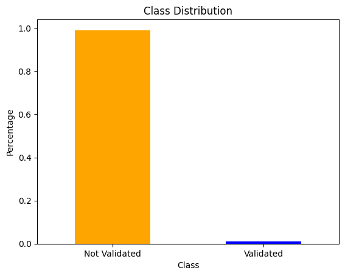

```python
import matplotlib.pyplot as plt

class_distribution.plot(kind='bar', color=['orange', 'blue'])
plt.title('Class Distribution')
plt.xlabel('Class')
plt.ylabel('Percentage')
plt.xticks(ticks=[0, 1], labels=['Not Validated', 'Validated'], rotation=0)
plt.show()
```

Target Feature have the high imbalance data

```python
# Convert the target variable to binary format (0 and 1)
filtered_business_df['validated'] = filtered_business_df['validated'].astype(int)
```

```python
filtered_business_df['validated']
```

```
0        0
1        0
2        0
3        0
4        0
        ..
86649    0
86650    0
86651    0
86652    0
86653    0
Name: validated, Length: 84079, dtype: int64
```

```python
# Assume business_df_encoded is your preprocessed DataFrame
# Define features and target variable
X = filtered_business_df.drop('validated', axis=1)
y = filtered_business_df['validated']
```

## Train Test Split

```python
# Step 1: Train-Test Split
X_train, X_test, y_train, y_test = train_test_split(X, y, test_size=0.2, random_state=42, stratify=y)
```

```python
# Step 3: Apply SMOTE
smote = SMOTE(random_state=42)
X_train_balanced, y_train_balanced = smote.fit_resample(X_train, y_train)
```

```python
# Check the class distribution after SMOTE
print("Class distribution after SMOTE:")
print(y_train_balanced.value_counts())
```

```
Class distribution after SMOTE:
validated
0    66613
1    66613
Name: count, dtype: int64
```

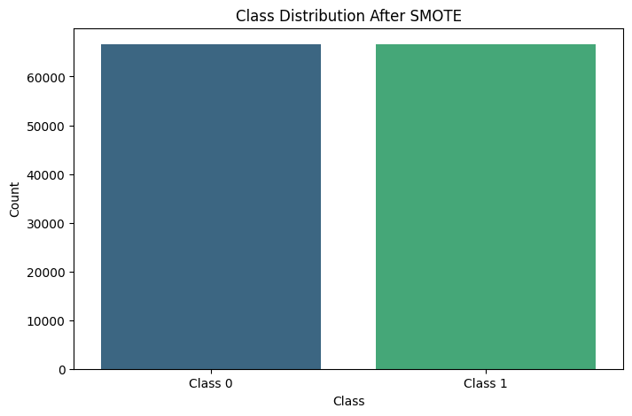

```python
import matplotlib.pyplot as plt
import seaborn as sns

# Check the class distribution after SMOTE
class_distribution = y_train_balanced.value_counts()

# Plotting
plt.figure(figsize=(8, 5))
sns.barplot(x=class_distribution.index, y=class_distribution.values, palette='viridis')
plt.title('Class Distribution After SMOTE')
plt.xlabel('Class')
plt.ylabel('Count')
plt.xticks(ticks=[0, 1], labels=['Class 0', 'Class 1'])  # Adjust labels based on your classes
plt.show()
```

```python
# Step 2: Scaling/Normalization
scaler = StandardScaler()
X_train_scaled = scaler.fit_transform(X_train)  # Fit on training data
X_test_scaled = scaler.transform(X_test)         # Transform test data
```

```python
print("Original X_train shape:", X_train.shape)
print("Original y_train shape:", y_train.shape)
print("X_train after SMOTE shape:", X_train_balanced.shape)
print("y_train after SMOTE shape:", y_train_balanced.shape)
print("X_train after Scaling shape:", X_train_scaled.shape)
print("X_test after Scaling shape:", X_test_scaled.shape)
```

```
Original X_train shape: (67263, 23)
Original y_train shape: (67263,)
X_train after SMOTE shape: (133226, 23)
y_train after SMOTE shape: (133226,)
X_train after Scaling shape: (67263, 23)
X_test after Scaling shape: (16816, 23)
```

```python
from sklearn.feature_selection import SelectKBest, f_classif

# Initializing SelectKBest
selector = SelectKBest(score_func=f_classif, k='all')  # You can adjust k as needed

X_train_selected = selector.fit_transform(X_train_balanced, y_train_balanced)

# Applying the same transformation to the test set
X_test_selected = selector.transform(X_test_scaled)
```

```python
X_train_balanced.info()
```

```
<class 'pandas.core.frame.DataFrame'>
RangeIndex: 133226 entries, 0 to 133225
Data columns (total 23 columns):
 #   Column                      Non-Null Count   Dtype
---  ------                      --------------   -----
 0   city                        133226 non-null  float64
 1   state                       133226 non-null  int64
 2   latitude                    133226 non-null  float64
 3   longitude                   133226 non-null  float64
 4   stars                       133226 non-null  float64
 5   review_count                133226 non-null  float64
 6   is_open                     133226 non-null  float64
 7   BusinessAcceptsCreditCards  133226 non-null  float64
 8   RestaurantsPriceRange2      133226 non-null  float64
 9   Restaurants                 133226 non-null  float64
 10  Food                        133226 non-null  float64
 11  Shopping                    133226 non-null  float64
 12  Home Services               133226 non-null  float64
 13  Beauty & Spas               133226 non-null  float64
 14  Nightlife                   133226 non-null  float64
 15  Health & Medical            133226 non-null  float64
 16  Local Services              133226 non-null  float64
 17  Bars                        133226 non-null  float64
 18  Automotive                  133226 non-null  float64
 19  garage                      133226 non-null  bool
 20  street                      133226 non-null  bool
 21  lot                         133226 non-null  bool
 22  valet                       133226 non-null  float64
dtypes: bool(3), float64(19), int64(1)
memory usage: 20.7 MB
```

```python
X_test_selected.shape
```

```
(16816, 23)
```

## XGBoost Model Building

```python
# Initializing the model
model = XGBClassifier(use_label_encoder=False, eval_metric='logloss')
```

```python
# Fit the model on the selected and scaled training data
model.fit(X_train_selected, y_train_balanced)
```

```
XGBClassifier(base_score=None, booster=None, callbacks=None,
              colsample_bylevel=None, colsample_bynode=None,
              colsample_bytree=None, device=None, early_stopping_rounds=None,
              enable_categorical=False, eval_metric='logloss',
              feature_types=None, gamma=None, grow_policy=None,
              importance_type=None, interaction_constraints=None,
              learning_rate=None, max_bin=None, max_cat_threshold=None,
              max_cat_to_onehot=None, max_delta_step=None, max_depth=None,
              max_leaves=None, min_child_weight=None, missing=nan,
              monotone_constraints=None, multi_strategy=None, n_estimators=None,
              n_jobs=None, num_parallel_tree=None, random_state=None, ...)
```

```python
# Predictions on the selected test data
y_train_pred = model.predict(X_train_selected)
y_test_pred = model.predict(X_test_selected)
```

```python
# Calculate accuracy
train_accuracy = accuracy_score(y_train_balanced, y_train_pred)
test_accuracy = accuracy_score(y_test, y_test_pred)

print(f"Train Accuracy: {train_accuracy:.4f}")
print(f"Test Accuracy: {test_accuracy:.4f}")
```

```
Train Accuracy: 0.8979
Test Accuracy: 0.2199
```

- The large gap between training and test accuracy indicates that the model has learned the training data well but fails to generalize to new, unseen data, likely due to memorization of patterns in the training set.
- Reason would be that we have used only business data and not merged with the review data set which we will be impletmenting once test deployment is done

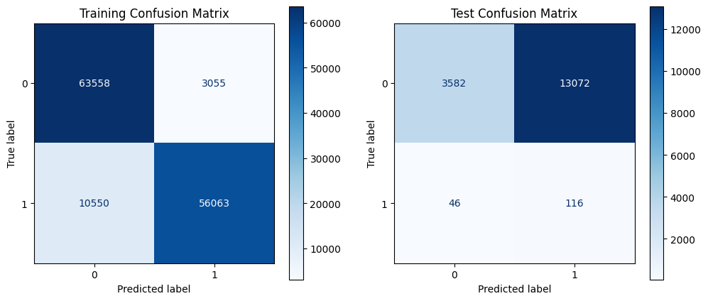

```python
# Confusion Matrices
cm_train = confusion_matrix(y_train_balanced, y_train_pred)
cm_test = confusion_matrix(y_test, y_test_pred)

# Display Confusion Matrices
fig, axes = plt.subplots(1, 2, figsize=(12, 5))
ConfusionMatrixDisplay(confusion_matrix=cm_train).plot(ax=axes[0], cmap='Blues')
axes[0].set_title('Training Confusion Matrix')
ConfusionMatrixDisplay(confusion_matrix=cm_test).plot(ax=axes[1], cmap='Blues')
axes[1].set_title('Test Confusion Matrix')
plt.show()
```

- The model exhibits signs of overfitting, as indicated by the significant performance gap between the training and test sets.
- The high false positive rate in the test set suggests that the model is struggling to generalize well to unseen data.
- The model may have learned patterns too specific to the training data, reducing its effectiveness on the test data.
- To address this, improvements such as cross-validation, regularization, or hyperparameter tuning can help enhance generalization and reduce false positives.

```python
# AUC Curve
y_train_prob = model.predict_proba(X_train_selected)[:, 1]  # Probability estimates for positive class
y_test_prob = model.predict_proba(X_test_selected)[:, 1]

# Compute ROC curve and AUC
fpr_train, tpr_train, _ = roc_curve(y_train_balanced, y_train_prob)
fpr_test, tpr_test, _ = roc_curve(y_test, y_test_prob)

auc_train = roc_auc_score(y_train_balanced, y_train_prob)
auc_test = roc_auc_score(y_test, y_test_prob)
```

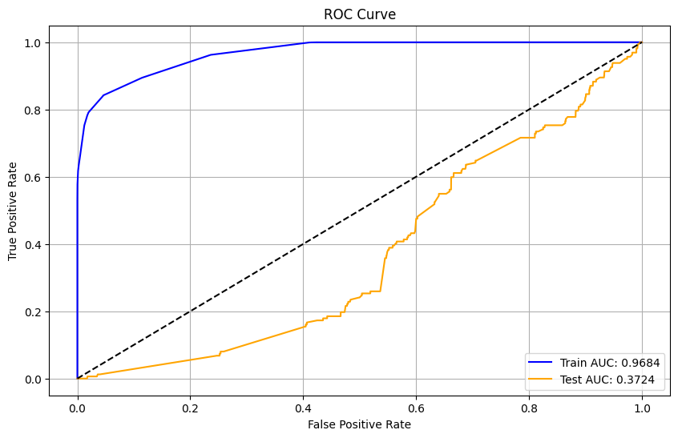

```python
# Plot AUC Curves
plt.figure(figsize=(10, 6))
plt.plot(fpr_train, tpr_train, label=f'Train AUC: {auc_train:.4f}', color='blue')
plt.plot(fpr_test, tpr_test, label=f'Test AUC: {auc_test:.4f}', color='orange')
plt.plot([0, 1], [0, 1], 'k--')  # Diagonal line
plt.xlabel('False Positive Rate')
plt.ylabel('True Positive Rate')
plt.title('ROC Curve')
plt.legend()
plt.grid()
plt.show()
```

- The ROC curve shows strong performance on the training set with an AUC of 0.9684, but the test set exhibits much lower performance with an AUC of 0.3724, highlighting overfitting.
- The significant drop in AUC from training to test set indicates that the model struggles to generalize and may need further tuning or regularization to improve test set performance.

```python
from sklearn.metrics import classification_report

# Generate predictions for the training and test sets
y_train_pred = model.predict(X_train_selected)  # Assuming you used X_train_selected
y_test_pred = model.predict(X_test_selected)    # Assuming you used X_test_selected

# Classification report for training set
print("Classification Report for Training Set:")
print(classification_report(y_train_balanced, y_train_pred))

# Classification report for test set
print("Classification Report for Test Set:")
print(classification_report(y_test, y_test_pred))
```

```
Classification Report for Training Set:
              precision    recall  f1-score   support

           0       0.86      0.95      0.90     66613
           1       0.95      0.84      0.89     66613

    accuracy                           0.90    133226
   macro avg       0.90      0.90      0.90    133226
weighted avg       0.90      0.90      0.90    133226

Classification Report for Test Set:
              precision    recall  f1-score   support

           0       0.99      0.22      0.35     16654
           1       0.01      0.72      0.02       162

    accuracy                           0.22     16816
   macro avg       0.50      0.47      0.19     16816
weighted avg       0.98      0.22      0.35     16816
```

```python
import pickle

# Specify the filename for your model
model_filename = 'xgboost_model.pkl'

# Save the model to a file
with open(model_filename, 'wb') as file:
    pickle.dump(model, file)

print(f"Model saved as {model_filename}")
```

```
Model saved as xgboost_model.pkl
```

## Cross validation

Doesn't help much

```python
from sklearn.model_selection import cross_val_score

# Perform 5-fold cross-validation
cv_scores = cross_val_score(model, X_train_selected, y_train_balanced, cv=5, scoring='accuracy')
print(f"Cross-validation scores: {cv_scores}")
print(f"Mean CV accuracy: {cv_scores.mean()}")
```

```
Cross-validation scores: [0.89090295 0.89926816 0.89990617 0.89619065 0.8934134 ]
Mean CV accuracy: 0.8959362664443626
```

```python
# Add regularization to the model
model = XGBClassifier(use_label_encoder=False, eval_metric='logloss', reg_alpha=0.1, reg_lambda=0.1)
model.fit(X_train_selected, y_train_balanced)
```

```
XGBClassifier(base_score=None, booster=None, callbacks=None,
              colsample_bylevel=None, colsample_bynode=None,
              colsample_bytree=None, device=None, early_stopping_rounds=None,
              enable_categorical=False, eval_metric='logloss',
              feature_types=None, gamma=None, grow_policy=None,
              importance_type=None, interaction_constraints=None,
              learning_rate=None, max_bin=None, max_cat_threshold=None,
              max_cat_to_onehot=None, max_delta_step=None, max_depth=None,
              max_leaves=None, min_child_weight=None, missing=nan,
              monotone_constraints=None, multi_strategy=None, n_estimators=None,
              n_jobs=None, num_parallel_tree=None, random_state=None, ...)
```

```python
# Make predictions on the test set
y_test_pred_improved = model.predict(X_test_selected)

# Evaluate the accuracy on the test set
test_accuracy_improved = accuracy_score(y_test, y_test_pred_improved)
print(f"Improved Test Accuracy: {test_accuracy_improved:.4f}")

# Generate the confusion matrix
from sklearn.metrics import confusion_matrix, classification_report

# Confusion matrix and classification report
conf_matrix_improved = confusion_matrix(y_test, y_test_pred_improved)
print("Confusion Matrix after improvements:")
print(conf_matrix_improved)

# Detailed classification report
classification_report_improved = classification_report(y_test, y_test_pred_improved)
print("Classification Report after improvements:")
print(classification_report_improved)
```

```
Improved Test Accuracy: 0.1035
Confusion Matrix after improvements:
[[ 1618 15036]
 [   40   122]]
Classification Report after improvements:
              precision    recall  f1-score   support

           0       0.98      0.10      0.18     16654
           1       0.01      0.75      0.02       162

    accuracy                           0.10     16816
   macro avg       0.49      0.43      0.10     16816
weighted avg       0.97      0.10      0.18     16816
```

```
Improved AUC Score: 0.3301
```

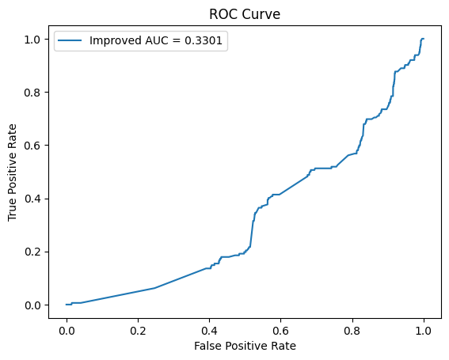

```python
from sklearn.metrics import roc_curve, roc_auc_score

# Predicted probabilities
y_test_proba_improved = model.predict_proba(X_test_selected)[:, 1]

# Compute AUC score
auc_score_improved = roc_auc_score(y_test, y_test_proba_improved)
print(f"Improved AUC Score: {auc_score_improved:.4f}")

# Plot ROC curve
fpr, tpr, _ = roc_curve(y_test, y_test_proba_improved)
plt.plot(fpr, tpr, label=f'Improved AUC = {auc_score_improved:.4f}')
plt.xlabel('False Positive Rate')
plt.ylabel('True Positive Rate')
plt.title('ROC Curve')
plt.legend()
plt.show()
```

- Despite applying cross-validation, regularization, the results have not significantly improved. The low test accuracy (0.1035) and the AUC score (0.3301) suggest that the model still struggles to generalize well to the test data.
- Inference: The primary issue here seems to be that we have only used the business data and have not yet incorporated the review dataset. This omission likely limits the model’s ability to capture more relevant patterns, leading to poor generalization. The review dataset likely contains valuable information that can help enhance prediction performance.
- Next Steps: We should merge the business and review datasets and build the model using this combined data. Incorporating both datasets will provide a more comprehensive view of the factors influencing the target variable and help improve model accuracy and AUC on the test set.

## ------------------------------THE END --------------------------

Rest of the thing are the test